# Math311_Exam1

Jackson Evans

3/26/2021

Question 1) Let’s assume there is no relationship between game outcome and game location. This is our null hypothesis. Our alternative hypothesis is that there is a relationship between game outcome and game location.

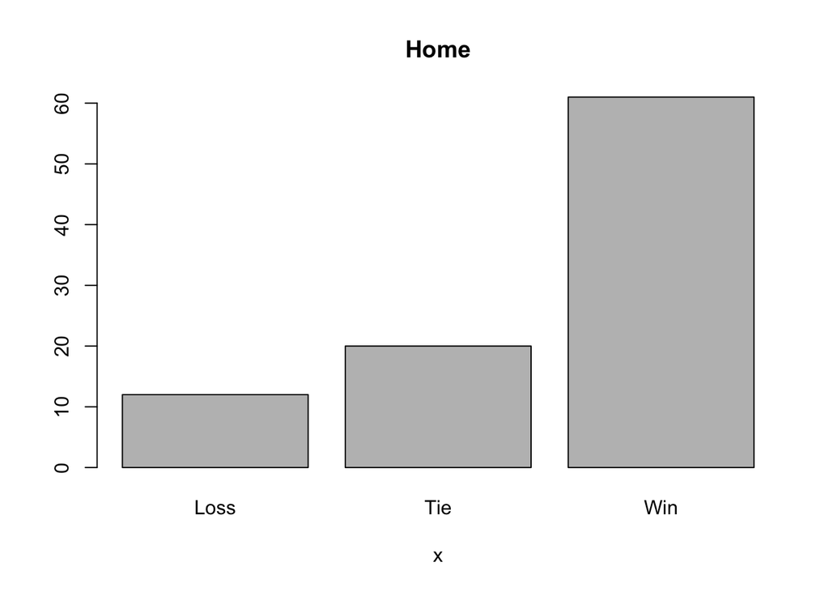

```r
home.values.final <- c(rep("Win", 61),
                          rep("Tie", 20),
                          rep("Loss", 12))
barplot(table(home.values.final), main="Home", xlab='x')
```

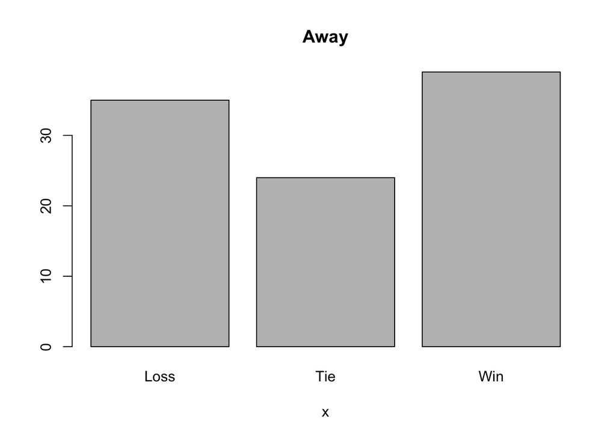

```r
away.values.final <- c(rep("Win", 39),
                          rep("Tie", 24),
                          rep("Loss", 35))
barplot(table(away.values.final), main="Away", xlab='x')
```

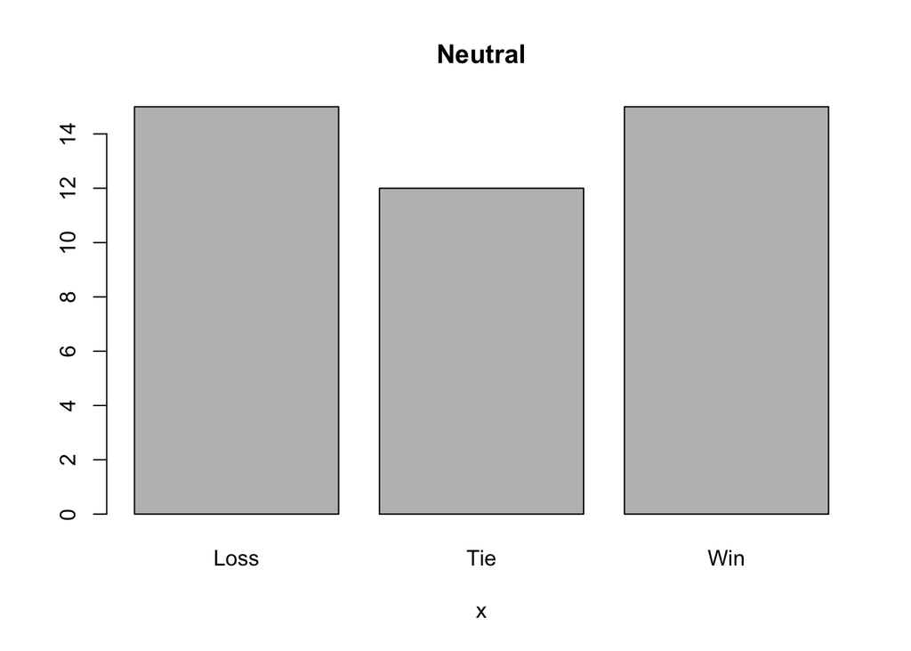

```r
neutral.values.final <- c(rep("Win", 15),
                       rep("Tie", 12),
                       rep("Loss", 15))
barplot(table(neutral.values.final), main="Neutral", xlab='x')
```

```r
home.values.final <- c(rep("Win", 61),
                          rep("Tie", 20),
                          rep("Loss", 12))

away.values.final <- c(rep("Win", 39),
                          rep("Tie", 24),
                          rep("Loss", 35))
neutral.values.final <- c(rep("Win", 15),
                       rep("Tie", 12),
                       rep("Loss", 15))

#Make a data set
manchester.data.final <- data.frame(location = c(rep("Home", 93),
                                                 rep("Away", 98),
                                                 rep("Neutral", 42)),
                                    result = c(home.values.final,
                                               away.values.final,
                                               neutral.values.final))
table(manchester.data.final)
```

```
##          result
## location  Loss Tie Win
##   Away      35  24  39
##   Home      12  20  61
##   Neutral   15  12  15
```

```r
#What would we expect to find in this table if
#the null hypothesis of "no relationship" were true?
observed <- table(manchester.data.final)

col.sums <- colSums(observed)
row.sums <- rowSums(observed)
grand.sum <- nrow(manchester.data.final)

row.matrix <- matrix(row.sums, ncol = 1)
col.matrix <- matrix(col.sums, ncol = 1)

#Expected matrix.
expected <- row.matrix %*% t(col.matrix) / grand.sum
expected
```

```
##          [,1]     [,2]     [,3]
## [1,] 26.07725 23.55365 48.36910
## [2,] 24.74678 22.35193 45.90129
## [3,] 11.17597 10.09442 20.72961
```

```r
#Chi-square contribution
chi.sq.cont <- (observed - expected)^2/expected

#Sum up our chi-square contributions
chi_sq_sum <- sum(chi.sq.cont)

#Calculate probability to the right of T = 19.90789 on a Chisq(4)
1 - pchisq(chi_sq_sum, 4)
```

```
## [1] 0.0005207467
```

After running a chi-square test for our observed data compared to the expected data, we get a statistically significant p value of 0.0005. Based on our data, we can safely conclude a correlation between home games and winning. Since winning home games are proportionally much larger (see graphs above), we can say that the difference is significant and not due to chance. As shown in the tables above, there is a large difference in the expected losses and actual losses in away games. Our expected value is far lower than the actual losses during away games. Our p-value therefore also lets us conclude that there is a correlation between loss and away games. Similarly, the expected wins for away games is far higher than the value observed, so our p-value allows us to conclude that there is significance in our observed value of wins for away games being low. Finally, while not as disparate, the observed values for neutral wins and losses are distinct. We should expect more wins and less losses than what was observed by the team for neutral locations and can therefore say there is a correlation between neutral games and lower win-rates.

Question 2) The Rayleigh Distribution has a CDF of 1-exp((-x^2)/2*(sigma^2))

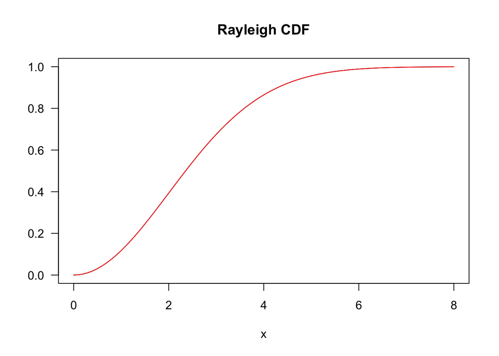

```r
a = 60
x = seq(0, 8, by=.1)
plot(x, 1-exp(-x^2/(8)), type="l", ylim=c(0,1), las=1, ylab="",
     main="Rayleigh CDF")
lines(x, 1-exp(-x^2/(8)), col="red")
```

In this problem, we are given a standard deviation of 2. Since we are considering Alex’s spending in a day, Xbar = X1 + X2 + … + X24 where X1, X2, …, X24 are i.i.d. Rayleigh Random Variables. We need to find when the sum of these variables are greater than 50. From C.O. Archer, we know that the mean of a Rayleigh random variable is root(pi/2) times sigma. When summing Rayleigh Random Variables, the mean is root(pi/2)*(sigma1 + sigma 2 + …), therefore we know that the mean for our sampling distribution is root(pi/2) times 48. So our sigma is 48. Therefore our CDF has x 50 and sigma 48, so we can represent this as 1-exp(-50^2/(2*48^2). But we are looking for the right tail, not the left tail of this. Therefore we seek:

```r
exp(-50^2/(2*48^2))
```

```
## [1] 0.581273
```

Hence, there is a 58% chance that Alex spends over $50 in a day.

Question 3) It is important to recognize that the data are of all textbooks of the university. Based on the data, which provides the entire population of textbooks at this university, we can already observe that there is a difference between average prices of math and sciences textbooks versus social science textbooks. This difference is $57.74407 (math and science minus social science).

For fun, let’s assume this data are a sample of a population of textbooks at this university. We should test whether or not this observed difference could be due to random chance.

Let’s assume that there is no difference in book prices by subject area. This will be our null hypothesis. Our alternative hypothesis is that there is a difference in textbook prices by subject area.

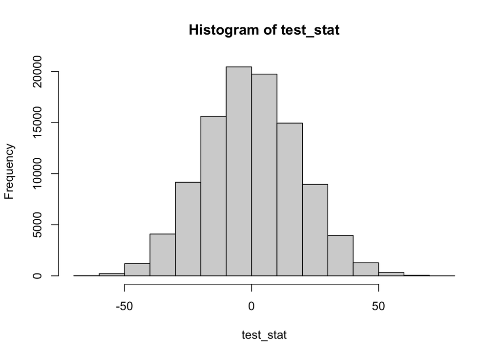

```r
library(resampledata)
#H0=no mean difference in book prices by subject area
#H1=difference in book prices by subject area
pool <- BookPrices$Price

ms <- subset(BookPrices, Area == "Math & Science")
ss <- subset(BookPrices, Area == "Social Sciences")

n1<- nrow(ms)

set.seed(12)
test_stat <- NULL
for(i in 1:100000){
  indexes <- sample(1:length(pool), size=n1, replace = FALSE) #random sample size 39

  group1 <- pool[indexes]
  group2 <- pool[-indexes]

  test_stat[i] <- mean(group1)-mean(group2)

}

#Calculate p-value
hist(test_stat)
```

```r
actual_stat <- mean(ms$Price)-mean(ss$Price)
mean(test_stat >= actual_stat)*2
```

```
## [1] 0.00174
```

Question 4) Working out will be uploaded to canvas. a) (2-sqrt(3))/2

```r
(2-sqrt(3))/2
```

```
## [1] 0.1339746
```

2. 3*sqrt(3)/8

```r
3*sqrt(3)/8
```

```
## [1] 0.6495191
```

3. using the left tail of the standard normal

```r
pnorm(((pi/6)-1)/(sqrt(pi - 3)/(sqrt(10))), mean=0, sd=1, lower.tail= TRUE, log.p = FALSE)
```

```
## [1] 3.119068e-05
```

Question 5) Male height in the US is ~ N(68, sd) Let’s assume that the sampled students are representative of male students at Middlebury.

Let’s run a bootstrap simulation.

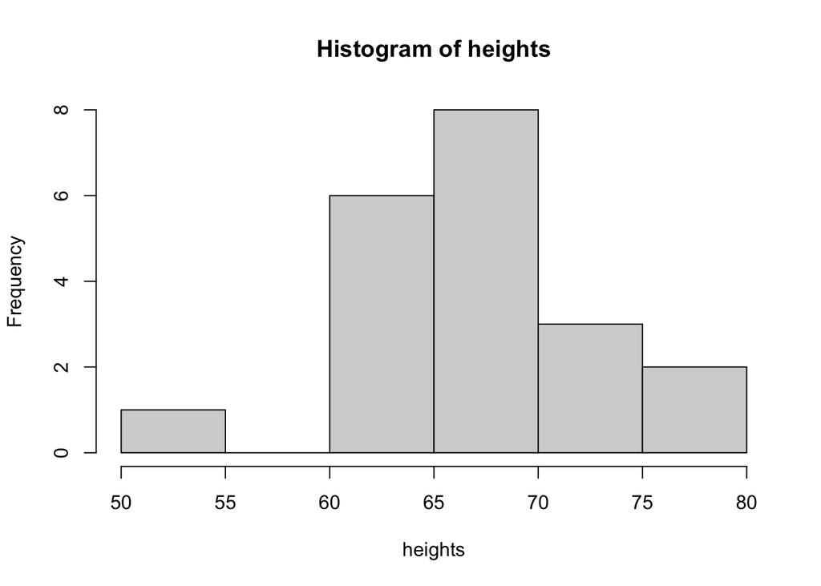

```r
#Male height ~N(68, sd)
#Assume that the sampled students are representative of male students at Midd
heights <- c(69.06, 65.49, 74.27, 65.64, 53.67,
             63.72, 67.40, 61.76, 65.41, 70.31, 67.04, 75.92, 77.82, 63.81, 74.95, 64.95, 64.08,
             63.31, 65.02, 68.01)
hist(heights)
```

```r
mean(heights)
```

```
## [1] 67.082
```

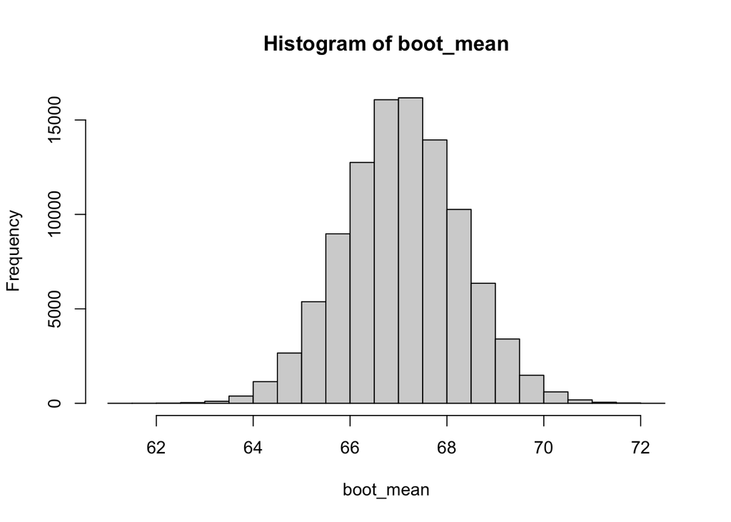

```r
boot_mean <- NULL

set.seed(128)
for(i in 1:100000){
  boot_mean[i] <- mean(sample(heights, size = length(heights), replace = TRUE))
}


#What does the bootstrapped distribution of the heights look like?
hist(boot_mean)
```

```r
mean(boot_mean >= 68)
```

```
## [1] 0.22378
```

```r
quantile(boot_mean, c(0.025, 0.975))
```

```
##     2.5%    97.5%
## 64.69300 69.46501
```

We have an observed mean from the sample of 67.082, about an inch lower than the center of the distribution for US Male height. The sample is too small, though, and the histogram shows it is not quite normal. After bootstrapping from just the sample, the histogram of the mean heights looks normal, but doesn’t seem to have the same center. However, finding a mean of 68 within our bootstrapped sample could happen around 23% of the time. 68 is well within a 95% confidence interval. Therefore we cannot say that male student heights at Middlebury College are not a random sample of US male adult heights. They could plausibly be a random sample of US male heights.

Question 6) a) 0.0546875. Written solution scanned and uploaded. b)

```r
students<-c(rep(TRUE, 13),rep(FALSE, 13)) #vector of names Professor Olvida knows
set.seed(129)
max_consec <- NULL
for(i in 1:10000){
  guesses <- sample(students, size=10, replace=FALSE) #sampling 10 students from our students vector
  max_consec[i] <- max(rle(guesses)$lengths[rle(guesses)$values]) #finding the max number of consecutive TRUE boolean values
}
mean(max_consec)
```

```
## [1] 2.7243
```

```r
var(max_consec)
```

```
## [1] 1.366826
```